# SHRS Education Analysis — 2024 Workforce Attainment (Table 5.3)

SHRS MQE Capstone Team

2026-02-13

```r
library(tidyverse)
library(scales)
library(knitr)
library(kableExtra)
```

# 0 — Configuration

```r
# ── EDIT THIS PATH ──
CSV_PATH <- file.path(path.expand("~"), "Documents", "SHRS_Analysis",
                       "market_analysis", "v3data", "projections_csv",
                       "education_csv", "2024", "education - Table 5.3.csv")

# 9-program crosswalk
soc_xwalk <- tribble(
  ~shrs_program, ~shrs_dept, ~soc_code,
  "SLP", "CSD", "29-1127",
  "AuD", "CSD", "29-1181",
  "HIM", "HIM", "29-9021",
  "OTD", "RST", "29-1122",
  "DPT", "RST", "29-1123",
  "PAS", "PAS", "29-1071",
  "AT",  "SMN", "29-9091",
  "DN",  "SMN", "29-1031",
  "SS",  "SMN", "29-1128"
)

target_socs <- soc_xwalk$soc_code

# Education levels low → high
edu_levels <- c(
  "Less than high school diploma",
  "High school diploma or equivalent",
  "Some college, no degree",
  "Associate's degree",
  "Bachelor's degree",
  "Master's degree",
  "Doctoral or professional degree"
)

# Colors
program_colors <- c(
  "SLP" = "#2c7bb6", "AuD" = "#abd9e9", "HIM" = "#8e44ad",
  "OTD" = "#e67e22", "DPT" = "#16a085", "PAS" = "#c0392b",
  "AT"  = "#fdae61", "DN"  = "#d7191c", "SS"  = "#1a9641"
)
signal_colors <- c("Green" = "#27ae60", "Yellow" = "#f39c12", "Red" = "#e74c3c")
```

# 1 — Load & Clean

```r
raw <- read_csv(CSV_PATH, show_col_types = FALSE)

# Standardize column names
names(raw)[1] <- "occ_title"
names(raw)[2] <- "soc_code"
names(raw)[3] <- "less_than_hs"
names(raw)[4] <- "hs_diploma"
names(raw)[5] <- "some_college"
names(raw)[6] <- "associates"
names(raw)[7] <- "bachelors"
names(raw)[8] <- "masters"
names(raw)[9] <- "doctoral"

# Clean
raw <- raw |>
  mutate(
    soc_code  = str_trim(soc_code),
    occ_title = str_remove_all(occ_title, "\\[\\d+\\]") |> str_trim()
  )

# Extract all-occupations benchmark row
benchmark_row <- raw |> filter(soc_code == "00-0000")

# Filter to SHRS targets
shrs_wide <- raw |>
  filter(soc_code %in% target_socs) |>
  left_join(soc_xwalk, by = "soc_code")

# Pivot long for plotting
shrs_long <- shrs_wide |>
  pivot_longer(
    cols = c(less_than_hs, hs_diploma, some_college, associates,
             bachelors, masters, doctoral),
    names_to = "edu_col", values_to = "pct"
  ) |>
  mutate(
    pct = as.numeric(pct),
    edu_level = case_when(
      edu_col == "less_than_hs" ~ "Less than high school diploma",
      edu_col == "hs_diploma"   ~ "High school diploma or equivalent",
      edu_col == "some_college" ~ "Some college, no degree",
      edu_col == "associates"   ~ "Associate's degree",
      edu_col == "bachelors"    ~ "Bachelor's degree",
      edu_col == "masters"      ~ "Master's degree",
      edu_col == "doctoral"     ~ "Doctoral or professional degree"
    ),
    edu_level = factor(edu_level, levels = edu_levels)
  )

# Benchmark long
bench_long <- benchmark_row |>
  pivot_longer(
    cols = c(less_than_hs, hs_diploma, some_college, associates,
             bachelors, masters, doctoral),
    names_to = "edu_col", values_to = "pct"
  ) |>
  mutate(
    pct = as.numeric(pct),
    edu_level = case_when(
      edu_col == "less_than_hs" ~ "Less than high school diploma",
      edu_col == "hs_diploma"   ~ "High school diploma or equivalent",
      edu_col == "some_college" ~ "Some college, no degree",
      edu_col == "associates"   ~ "Associate's degree",
      edu_col == "bachelors"    ~ "Bachelor's degree",
      edu_col == "masters"      ~ "Master's degree",
      edu_col == "doctoral"     ~ "Doctoral or professional degree"
    ),
    edu_level = factor(edu_level, levels = edu_levels)
  )
```

### Data Quality Check

```r
# Verify all 9 programs loaded
n_found <- nrow(shrs_wide)
cat(paste0("**Programs found:** ", n_found, " of 9\n\n"))
```

**Programs found:** 9 of 9

```r
# Check AT/HIM duplication
at_vals <- shrs_wide |> filter(soc_code == "29-9091") |>
  select(less_than_hs:doctoral) |> as.numeric()
him_vals <- shrs_wide |> filter(soc_code == "29-9021") |>
  select(less_than_hs:doctoral) |> as.numeric()
if (identical(at_vals, him_vals)) {
  cat("> **Note:** AT (29-9091) and HIM (29-9021) have identical education ",
      "distributions in this table. BLS uses a shared broader-group estimate ",
      "(footnote [1] in source). Interpret with caution.\n")
}
```

> **Note:** AT (29-9091) and HIM (29-9021) have identical education distributions in this table. BLS uses a shared broader-group estimate (footnote [1] in source). Interpret with caution.

```r
# Check all rows sum to ~100%
row_sums <- shrs_long |>
  group_by(shrs_program) |>
  summarise(total = sum(pct, na.rm = TRUE), .groups = "drop")

cat(paste0("\n**Row sums (should be ~100):** ",
           paste(row_sums$shrs_program, "=", round(row_sums$total, 1),
                 collapse = ", "), "\n"))
```

**Row sums (should be ~100):** AT = 100, AuD = 100, DN = 99.9, DPT = 100.1, HIM = 100, OTD = 100.1, PAS = 100.1, SLP = 100, SS = 100

# 2 — Workforce Education Distribution

## 2.1 Stacked Distribution

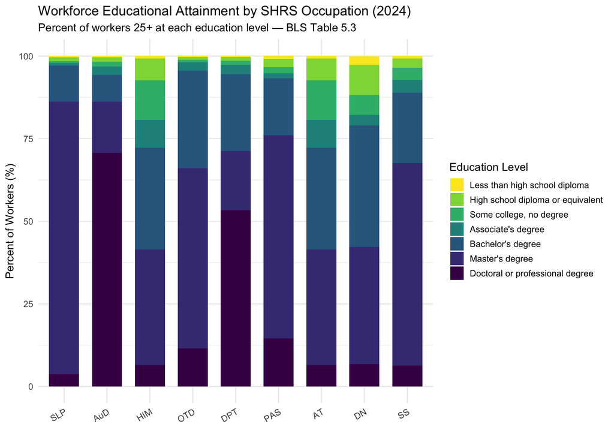

```r
shrs_long |>
  ggplot(aes(x = factor(shrs_program, levels = soc_xwalk$shrs_program),
             y = pct, fill = edu_level)) +
  geom_col(width = 0.7) +
  scale_fill_viridis_d(option = "D", direction = -1, name = "Education Level") +
  labs(
    title = "Workforce Educational Attainment by SHRS Occupation (2024)",
    subtitle = "Percent of workers 25+ at each education level — BLS Table 5.3",
    x = NULL, y = "Percent of Workers (%)"
  ) +
  theme_minimal(base_size = 13) +
  theme(axis.text.x = element_text(angle = 30, hjust = 1))
```

## 2.2 Wide Summary Table

```r
shrs_wide |>
  select(Program = shrs_program, Dept = shrs_dept,
         `< HS` = less_than_hs, `HS` = hs_diploma,
         `Some Col` = some_college, `Assoc` = associates,
         `Bach` = bachelors, `Master` = masters,
         `Doct` = doctoral) |>
  arrange(factor(Program, levels = soc_xwalk$shrs_program)) |>
  kable(digits = 1,
        caption = "Education Attainment Distribution (% of Workers 25+, 2024)") |>
  kable_styling(bootstrap_options = c("striped", "hover"), full_width = FALSE)
```

Education Attainment Distribution (% of Workers 25+, 2024)

| Program | Dept | < HS | HS | Some Col | Assoc | Bach | Master | Doct |
| --- | --- | --- | --- | --- | --- | --- | --- | --- |
| SLP | CSD | 0.4 | 1.1 | 0.6 | 0.8 | 10.9 | 82.5 | 3.7 |
| AuD | CSD | 0.4 | 1.3 | 1.5 | 2.5 | 8.1 | 15.5 | 70.7 |
| HIM | HIM | 0.8 | 6.5 | 12.0 | 8.5 | 30.8 | 34.9 | 6.5 |
| OTD | RST | 0.4 | 0.8 | 0.8 | 2.5 | 29.6 | 54.5 | 11.5 |
| DPT | RST | 0.4 | 1.1 | 1.3 | 2.8 | 23.2 | 18.0 | 53.3 |
| PAS | PAS | 1.0 | 2.5 | 1.8 | 1.6 | 17.2 | 61.5 | 14.5 |
| AT | SMN | 0.8 | 6.5 | 12.0 | 8.5 | 30.8 | 34.9 | 6.5 |
| DN | SMN | 2.6 | 9.1 | 6.0 | 3.2 | 36.8 | 35.4 | 6.8 |
| SS | SMN | 0.8 | 2.8 | 3.6 | 3.9 | 21.3 | 61.3 | 6.3 |

# 3 — Graduate-Degree Concentration

```r
grad_share_2024 <- shrs_wide |>
  mutate(grad_pct = as.numeric(masters) + as.numeric(doctoral)) |>
  select(shrs_program, shrs_dept, soc_code, grad_pct)

all_occ_grad_2024 <- as.numeric(benchmark_row$masters) +
                     as.numeric(benchmark_row$doctoral)

grad_share_2024 <- grad_share_2024 |>
  mutate(
    benchmark = all_occ_grad_2024,
    ratio_to_benchmark = round(grad_pct / all_occ_grad_2024, 2)
  )
```

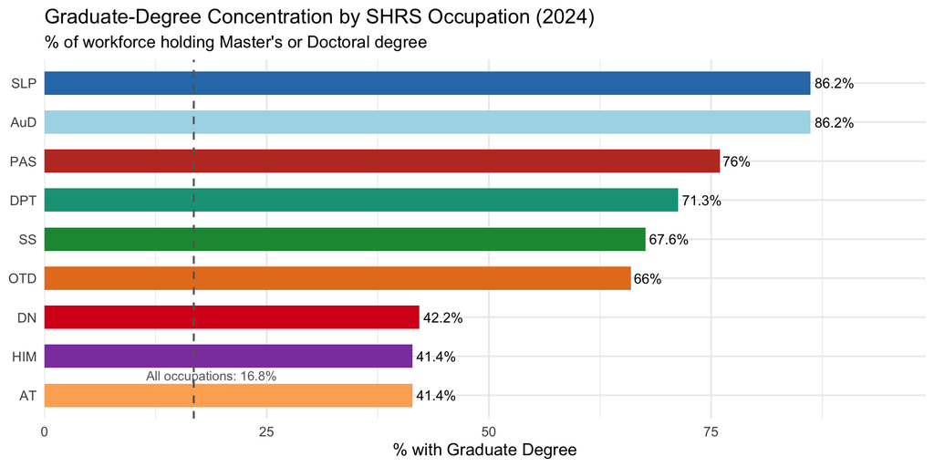

```r
grad_share_2024 |>
  ggplot(aes(x = reorder(shrs_program, grad_pct), y = grad_pct,
             fill = shrs_program)) +
  geom_col(width = 0.6) +
  geom_hline(yintercept = all_occ_grad_2024, linetype = "dashed",
             color = "gray40", linewidth = 0.7) +
  annotate("text", x = 1.5, y = all_occ_grad_2024 + 2,
           label = paste0("All occupations: ", all_occ_grad_2024, "%"),
           size = 3.5, color = "gray40") +
  geom_text(aes(label = paste0(round(grad_pct, 1), "%")),
            hjust = -0.1, size = 3.8) +
  coord_flip() +
  scale_fill_manual(values = program_colors) +
  scale_y_continuous(expand = expansion(mult = c(0, 0.15))) +
  labs(
    title = "Graduate-Degree Concentration by SHRS Occupation (2024)",
    subtitle = "% of workforce holding Master's or Doctoral degree",
    x = NULL, y = "% with Graduate Degree"
  ) +
  theme_minimal(base_size = 13) +
  theme(legend.position = "none")
```

```r
grad_share_2024 |>
  select(Program = shrs_program, `Grad %` = grad_pct,
         `All Occ Benchmark` = benchmark,
         `Ratio to Benchmark` = ratio_to_benchmark) |>
  arrange(desc(`Grad %`)) |>
  kable(digits = 1,
        caption = "Graduate Degree Concentration vs All-Occupations Benchmark") |>
  kable_styling(bootstrap_options = c("striped", "hover"), full_width = FALSE)
```

Graduate Degree Concentration vs All-Occupations Benchmark

| Program | Grad % | All Occ Benchmark | Ratio to Benchmark |
| --- | --- | --- | --- |
| SLP | 86.2 | 16.8 | 5.1 |
| AuD | 86.2 | 16.8 | 5.1 |
| PAS | 76.0 | 16.8 | 4.5 |
| DPT | 71.3 | 16.8 | 4.2 |
| SS | 67.6 | 16.8 | 4.0 |
| OTD | 66.0 | 16.8 | 3.9 |
| DN | 42.2 | 16.8 | 2.5 |
| HIM | 41.4 | 16.8 | 2.5 |
| AT | 41.4 | 16.8 | 2.5 |

# 4 — Dominant Education Level (Workforce Mode)

```r
dominant_edu_2024 <- shrs_long |>
  group_by(shrs_program, shrs_dept, soc_code) |>
  slice_max(pct, n = 1, with_ties = FALSE) |>
  ungroup() |>
  select(shrs_program, shrs_dept, soc_code,
         dominant_edu = edu_level, dominant_pct = pct)

dominant_edu_2024 |>
  select(Program = shrs_program, Dept = shrs_dept,
         `Most Common Education` = dominant_edu,
         `% of Workforce` = dominant_pct) |>
  arrange(factor(Program, levels = soc_xwalk$shrs_program)) |>
  kable(digits = 1,
        caption = "Most Common Education Level in Workforce (2024)") |>
  kable_styling(bootstrap_options = c("striped", "hover"), full_width = FALSE)
```

Most Common Education Level in Workforce (2024)

| Program | Dept | Most Common Education | % of Workforce |
| --- | --- | --- | --- |
| SLP | CSD | Master’s degree | 82.5 |
| AuD | CSD | Doctoral or professional degree | 70.7 |
| HIM | HIM | Master’s degree | 34.9 |
| OTD | RST | Master’s degree | 54.5 |
| DPT | RST | Doctoral or professional degree | 53.3 |
| PAS | PAS | Master’s degree | 61.5 |
| AT | SMN | Master’s degree | 34.9 |
| DN | SMN | Bachelor’s degree | 36.8 |
| SS | SMN | Master’s degree | 61.3 |

# 5 — Comparison to All-Occupations Benchmark

How does each SHRS occupation’s education profile differ from the economy-wide distribution?

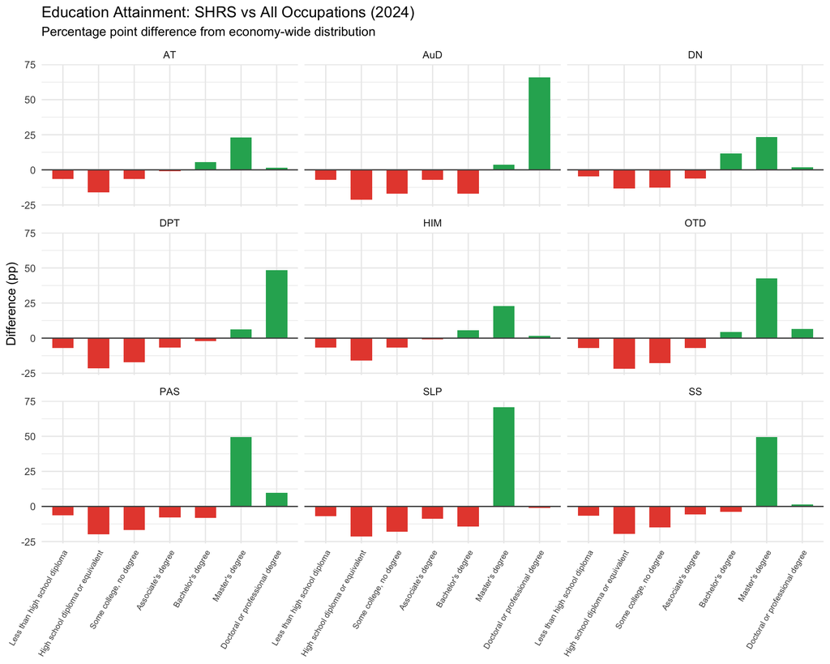

```r
# Compute difference from benchmark for each level
bench_lookup <- bench_long |> select(edu_level, bench_pct = pct)

diff_from_bench <- shrs_long |>
  left_join(bench_lookup, by = "edu_level") |>
  mutate(diff_pp = pct - bench_pct)

diff_from_bench |>
  ggplot(aes(x = edu_level, y = diff_pp, fill = diff_pp > 0)) +
  geom_col(width = 0.6) +
  geom_hline(yintercept = 0, color = "gray30") +
  facet_wrap(~ shrs_program, ncol = 3) +
  scale_fill_manual(values = c("TRUE" = "#27ae60", "FALSE" = "#e74c3c"),
                    guide = "none") +
  labs(
    title = "Education Attainment: SHRS vs All Occupations (2024)",
    subtitle = "Percentage point difference from economy-wide distribution",
    x = NULL, y = "Difference (pp)"
  ) +
  theme_minimal(base_size = 11) +
  theme(axis.text.x = element_text(angle = 60, hjust = 1, size = 7))
```

# 6 — Attainment Scorecard (0–100)

Three dimensions scored 0–100, capturing how concentrated, graduate-heavy, and specialized each occupation’s workforce is.

[output not shown]

```r
attain_scorecard_2024 <- shrs_wide |>
  mutate(
    grad_pct = as.numeric(masters) + as.numeric(doctoral),
    sub_bach_pct = as.numeric(less_than_hs) + as.numeric(hs_diploma) +
                   as.numeric(some_college)
  ) |>
  left_join(dominant_edu_2024 |> select(shrs_program, dominant_pct),
            by = "shrs_program") |>
  mutate(
    d1_grad_intensity = round(pmin(grad_pct / all_occ_grad_2024 * 50, 100), 1),
    d2_concentration  = round(dominant_pct, 1),
    d3_sub_bach_ctrl  = round(100 - sub_bach_pct, 1),
    composite = round((d1_grad_intensity + d2_concentration + d3_sub_bach_ctrl) / 3, 1),
    signal = case_when(
      composite >= 70 ~ "Green",
      composite >= 50 ~ "Yellow",
      TRUE            ~ "Red"
    )
  )
```

```r
attain_ordered <- attain_scorecard_2024 |> arrange(desc(composite))

attain_ordered |>
  select(Program = shrs_program, Dept = shrs_dept,
         `Grad Intensity` = d1_grad_intensity,
         Concentration = d2_concentration,
         `Sub-Bach Ctrl` = d3_sub_bach_ctrl,
         Composite = composite,
         Signal = signal) |>
  kable(digits = 1,
        caption = "Workforce Attainment Scorecard (0-100, 2024)") |>
  kable_styling(bootstrap_options = c("striped", "hover"), full_width = FALSE) |>
  column_spec(7, color = "white",
              background = ifelse(attain_ordered$signal == "Green", "#27ae60",
                           ifelse(attain_ordered$signal == "Yellow", "#f39c12",
                                  "#e74c3c")))
```

Workforce Attainment Scorecard (0-100, 2024)

| Program | Dept | Grad Intensity | Concentration | Sub-Bach Ctrl | Composite | Signal |
| --- | --- | --- | --- | --- | --- | --- |
| SLP | CSD | 100 | 82.5 | 97.9 | 93.5 | Green |
| AuD | CSD | 100 | 70.7 | 96.8 | 89.2 | Green |
| PAS | PAS | 100 | 61.5 | 94.7 | 85.4 | Green |
| SS | SMN | 100 | 61.3 | 92.8 | 84.7 | Green |
| OTD | RST | 100 | 54.5 | 98.0 | 84.2 | Green |
| DPT | RST | 100 | 53.3 | 97.2 | 83.5 | Green |
| DN | SMN | 100 | 36.8 | 82.3 | 73.0 | Green |
| HIM | HIM | 100 | 34.9 | 80.7 | 71.9 | Green |
| AT | SMN | 100 | 34.9 | 80.7 | 71.9 | Green |

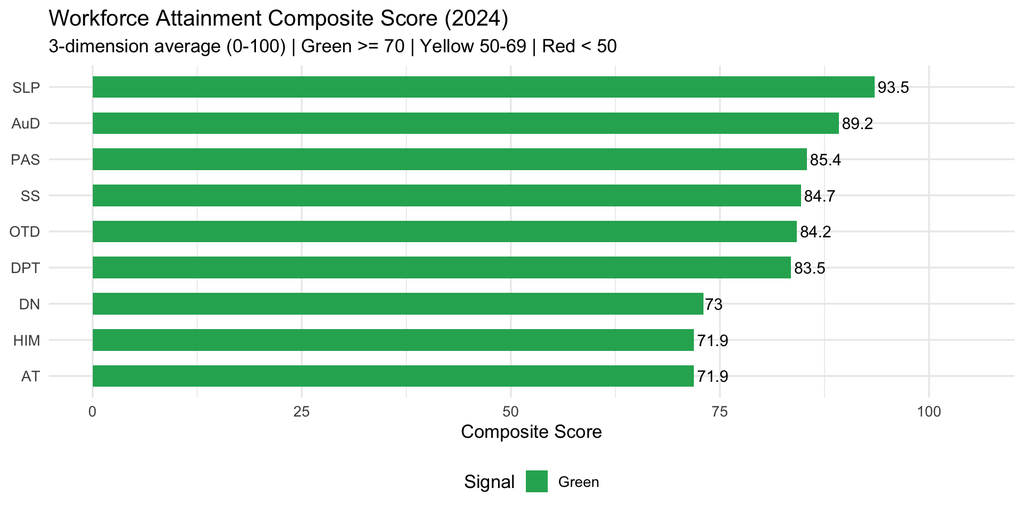

```r
attain_scorecard_2024 |>
  ggplot(aes(x = reorder(shrs_program, composite), y = composite,
             fill = signal)) +
  geom_col(width = 0.6) +
  geom_text(aes(label = composite), hjust = -0.1, size = 4) +
  coord_flip() +
  scale_fill_manual(values = signal_colors, name = "Signal") +
  scale_y_continuous(limits = c(0, 105)) +
  labs(
    title = "Workforce Attainment Composite Score (2024)",
    subtitle = "3-dimension average (0-100) | Green >= 70 | Yellow 50-69 | Red < 50",
    x = NULL, y = "Composite Score"
  ) +
  theme_minimal(base_size = 13) +
  theme(legend.position = "bottom")
```

# 7 — Stored Outputs

```r
# All stored variables for downstream use
t53_2024_shrs_wide       <- shrs_wide
t53_2024_shrs_long       <- shrs_long
t53_2024_benchmark       <- bench_long
t53_2024_grad_share      <- grad_share_2024
t53_2024_dominant_edu    <- dominant_edu_2024
t53_2024_diff_benchmark  <- diff_from_bench
t53_2024_scorecard       <- attain_scorecard_2024
t53_2024_all_occ_grad    <- all_occ_grad_2024
```

```r
cat("| Variable | Description | Dimensions |\n")
```

Variable | Description | Dimensions |

```r
cat("|---|---|---|\n")
```

|—|—|—|

```r
cat(paste0("| `t53_2024_shrs_wide` | Wide-format attainment (9 programs x 7 levels) | ",
           nrow(t53_2024_shrs_wide), " x ", ncol(t53_2024_shrs_wide), " |\n"))
```

`t53_2024_shrs_wide` | Wide-format attainment (9 programs x 7 levels) | 9 x 11 |

```r
cat(paste0("| `t53_2024_shrs_long` | Long-format attainment for plotting | ",
           nrow(t53_2024_shrs_long), " x ", ncol(t53_2024_shrs_long), " |\n"))
```

`t53_2024_shrs_long` | Long-format attainment for plotting | 63 x 7 |

```r
cat(paste0("| `t53_2024_benchmark` | All-occupations benchmark (long) | ",
           nrow(t53_2024_benchmark), " x ", ncol(t53_2024_benchmark), " |\n"))
```

`t53_2024_benchmark` | All-occupations benchmark (long) | 7 x 5 |

```r
cat(paste0("| `t53_2024_grad_share` | Graduate concentration + ratio | ",
           nrow(t53_2024_grad_share), " x ", ncol(t53_2024_grad_share), " |\n"))
```

`t53_2024_grad_share` | Graduate concentration + ratio | 9 x 6 |

```r
cat(paste0("| `t53_2024_dominant_edu` | Workforce mode per program | ",
           nrow(t53_2024_dominant_edu), " x ", ncol(t53_2024_dominant_edu), " |\n"))
```

`t53_2024_dominant_edu` | Workforce mode per program | 9 x 5 |

```r
cat(paste0("| `t53_2024_diff_benchmark` | Difference from all-occ by level | ",
           nrow(t53_2024_diff_benchmark), " x ", ncol(t53_2024_diff_benchmark), " |\n"))
```

`t53_2024_diff_benchmark` | Difference from all-occ by level | 63 x 9 |

```r
cat(paste0("| `t53_2024_scorecard` | 3-dim attainment scorecard (0-100) | ",
           nrow(t53_2024_scorecard), " x ", ncol(t53_2024_scorecard), " |\n"))
```

`t53_2024_scorecard` | 3-dim attainment scorecard (0-100) | 9 x 19 |

```r
cat("| `t53_2024_all_occ_grad` | All-occ graduate % benchmark (scalar) | 1 |\n")
```

`t53_2024_all_occ_grad` | All-occ graduate % benchmark (scalar) | 1 |

# Appendix

**Source:** BLS Employment Projections, Table 5.3 — Educational attainment for workers age 25 and older by detailed occupation, 2024 vintage.

**Known limitation:** AT (29-9091) and HIM (29-9021) share identical distributions (BLS broader-group estimate).